# COPE-BP Annual Meeting - WP1 mapping readiness

Diego Pajarito

2025-12-08

## COPE-BP Mapping Clusters Markdown document

This R Markdown document is designed for sharing resources at the Annual meeting and contain analysis of fieldwork and survey data prepared within the WP1.

This document is automatically generated using the option **Knit** within an R-Markdown file. Therefore some content might not display correctly. Please contact the Diego Pajarito Grajales for any additional requirement.

### Initial setup

The workflow uses different libraries such as **haven** and **readxl** for data management as well as [sf](https://r-spatial.github.io/sf/), **dplyr** and [leaflet](https://leafletjs.com) for geospatial data management.

## Analysing catchment areas as strata for defining clusters

In order to visualise the geospatial location of the surveyed facilities, there is an option to merge mapping data and survey data. This is done using the merge option

**Clusters based on catchment areas** Despite their location, some pharmacies might serve population from different areas in the city. The survey asks broadly where the clients come from. We use this information to understand how this would serve for the sampling design and pharmacy clusters.

We reorganised the original data to identify the areas/neighbourhoods/union councils/wards the clients come from.

### **Bangladesh**

The areas were captured as codded values, so we mapped them with their labels to improve readability.

This is an example of how the values were coded:

```r
type_cities
```

```
##                                     1                                     2
## "Dhaka North City Corporation (DNCC)" "Dhaka South City Corporation (DSCC)"
##                                     3                                     4
##                "Narsingdi Paurashava"                "Ghorashal Paurashava"
```

While the majority of pharmacies report a single area as the one where their clients come from, there are some others that report additional ones. We can see the proportion of these in the following plot. We will continue analysing those pharmacies that report clients coming from additional areas.

[figure not shown]

When detailing how these pharmacies reporting their clients coming from other areas refer to those sites, we find that the survey capture pharmacies reporting clients coming from areas out of our study areas (e.g., Others) or unknown areas (e.g., I don’t know). The plot below shows that not all reported locations are known and this would make isolating pharmacies based on the origin of their clients to prevent cross contamination more difficult.

Note: This analysis does not consider those locations reported as a free text in the survey. This require additional case-specific analysis.

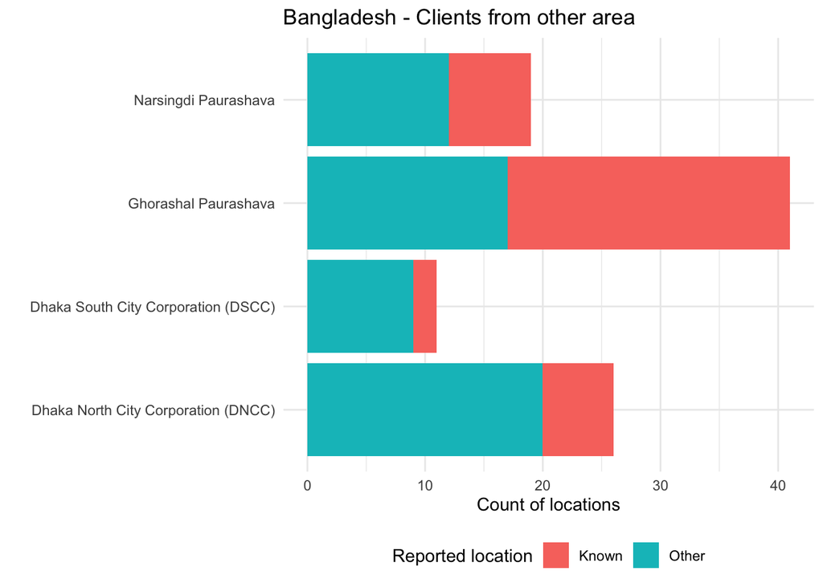

Still it is possible to work with the subset of pharmacies i) reporting clients coming form a different area and ii) reporting a known location. We use a visualisation technique to link each pharmacy and the reported location to understand the spatial relationships between the pharmacy and the catchment area. Note: This analysis focuses on those links with areas different to the one the pharmacy is located at. It is safe to assume that all pharmacies serve clients from the area they are located.

Note: that the team did not obtain admin boundaries for “Ghorashal Paurashava”

Note: For the Bangladesh analysis, we only obtained data about Dhaka wards. Analysis of areas in Narsingdi is pending

[interactive chart not shown]

### **Pakistan**

The areas were captured as codded values, so we mapped them with their labels to improve readability.

This is an example of how the values were coded:

```r
type_cities
```

```
##            1            2
##   "Peshawar" "Abbottabad"
```

In Pakistan multiple pharmacies report more areas where their clients come from. We can see the proportion of these in the following plot as a wider variety. We will continue analysing those pharmacies that report clients coming from additional areas.

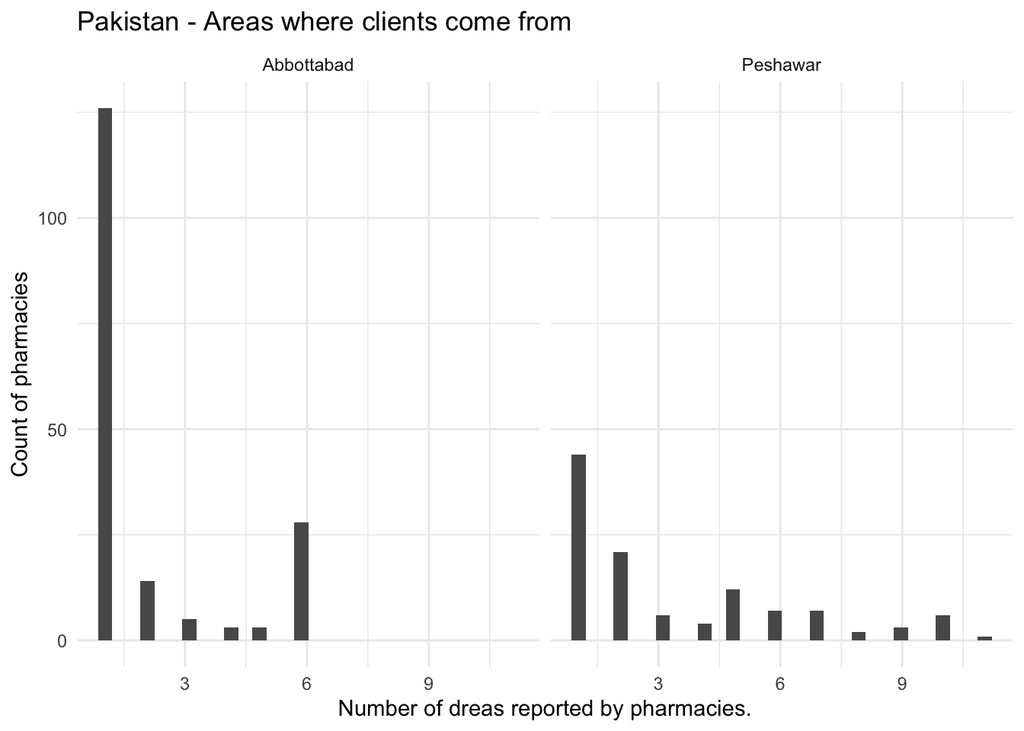

As in Bangladesh, pharmacies reporting clients coming from more areas different from where they are located. The plot below shows that not all reported locations are known and this would make isolating pharmacies based on the origin of their clients to prevent cross contamination more difficult.

Note: This analysis does not consider those locations reported as a free text in the survey. This require additional case-specific analysis.

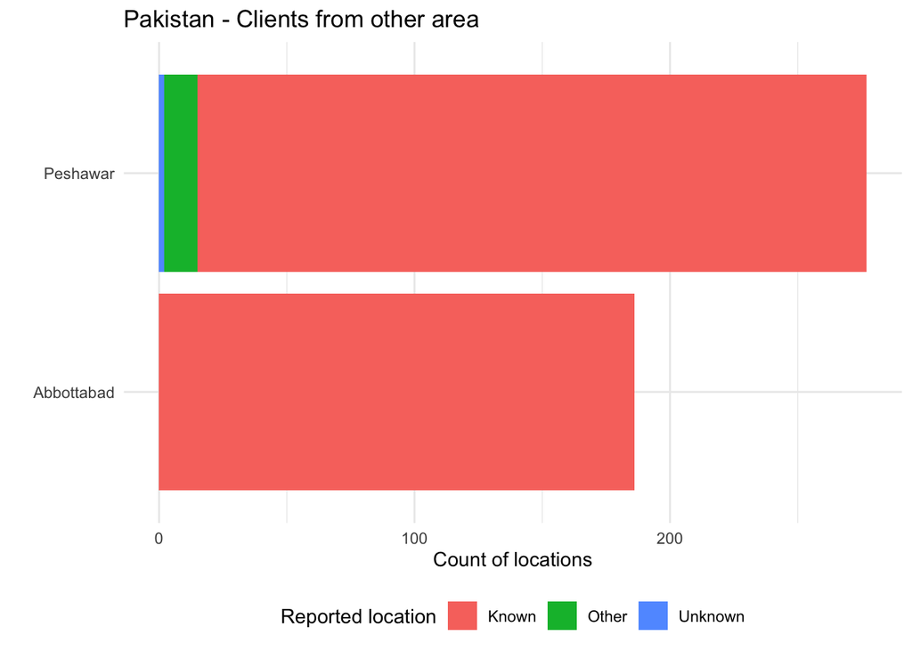

In this case, there are just a few pharmacies reporting unknown areas where their clients come from. It is feasible to analyse the links between the pharmacies and the reported known location. We use a visualisation technique to link each pharmacy and the reported location to understand the spatial relationships between the pharmacy and the catchment area. Note: This analysis focuses on those links with areas different to the one the pharmacy is located at. It is safe to assume that all pharmacies serve clients from the area they are located.

Note: Some of the areas were mapped to bigger divisions than the ones recorded in the survey (e.g., Hassan Garhi I, Malikpura)

[interactive chart not shown]